# Create main data frame

2019-06-12

# 1 Setup

```r
library(tidyverse)
library(sjmisc)
library(here)
```

Where am I?

```r
here::here()
```

```
## [1] "/Users/sebastiansaueruser/Documents/research/Achtsamkeit_Studien/Necker/necker-cube-replication-saueretal2012"
```

Load raw data:

```r
rawdata <- readxl::read_xlsx(paste0(here::here(), "/raw-data/Rohdaten.xlsx"))
```

Add id:

```r
rawdata <- rawdata %>%
  add_id(var = "id")
```

Check names:

```r
names(rawdata)[c(30, 31)]
```

```
## [1] "MA01_15" "MA01_16"
```

Check level-1 (l1) data (reaction times):

```r
head(rawdata$NW03_01)
```

```
## [1] "24771,6371,20708,8869,10777,8835,8982,3548,22205,3268,4450,7777,3765,1169,15214"
## [2] "3541,12364,7215,12253,11850,9157,8360,7324,18277,2854,1699,2610,5697,5684,3131,6044,4037,4943,3464,9456,4509,3048,5518,5657,10887,6082"
## [3] "9482,9964,11916,2086,7856,1544,1915,9249,11002,5050,8741,7044,4086,7787,4895,7992,2628,6382,6165,5441,9267,16876,7940"
## [4] "5530,2796,4075,2587,6330,4349,5247,6030,3427,7760,4451,7414,2712,6752,7181,4517,4377,8385,2527,4987,2801,3817,8013,5499,1530,5713,5310,9034,3707,2503,6139,6593,7354,2824,6451"
## [5] "1792"
## [6] "7227,5550,618,5747,545,4264,3919,4586,7248,5015,2990,562,2965,2318,2119,1819,6153,5383,1491,4138,2470,527,2355,2528,2303,2899,1857,1710,3231,1668,2373,559,4909,6112,2379,10351,3119,10468,6900,8964,3102,8255,4031,6230,4602"
```

## 1.1 Extract l1 data

test it:

```r
rawdata$NW03_01[1] %>% str_split(pattern=",") %>% `[[`(1) %>% parse_number() %>% str()
```

```
##  num [1:15] 24771 6371 20708 8869 10777 ...
```

### 1.1.1 block 1: “flip as often as you can”

Extract reaction time (rt) data, block 1 (flip as often as you can):

```r
flip_rt <- rawdata$NW04_01 %>%
  map(~str_split(., pattern = ",")) %>%
  map(~`[[`(., 1)) %>%  # extract string element from list, not list, as parse_number needs string element
  map(~ parse_number(.))
```

Get descriptives:

```r
flip_stats <- list()

flip_stats$md_flip <- flip_rt %>% flatten_dbl() %>% median(na.rm = T)
flip_stats$mean_flip <- flip_rt %>% flatten_dbl() %>% mean(na.rm = T)
flip_stats$sd_flip <- flip_rt %>% flatten_dbl() %>% sd(na.rm = T)
flip_stats$iqr_flip <- flip_rt %>% flatten_dbl() %>% median(na.rm = T)


flip_stats
```

```
## $md_flip
## [1] 1055
##
## $mean_flip
## [1] 1574.141
##
## $sd_flip
## [1] 2686.491
##
## $iqr_flip
## [1] 1055
```

Maybe better as as tibble:

```r
flip_rt_sum <- flip_stats %>%
  flatten_dbl() %>%
  enframe(name = "trial", value = "rt") %>%
  drop_na() %>%
  summarise(type = "flip",
            md_rt = median(rt),
            mean_rt = mean(rt),
            sd_rt = sd(rt),
            iqr_rt = IQR(rt)
            )


flip_rt_sum
```

```
## # A tibble: 1 x 5
##   type  md_rt mean_rt sd_rt iqr_rt
##   <chr> <dbl>   <dbl> <dbl>  <dbl>
## 1 flip  1315.   1593.  769.   797.
```

Visualize it:

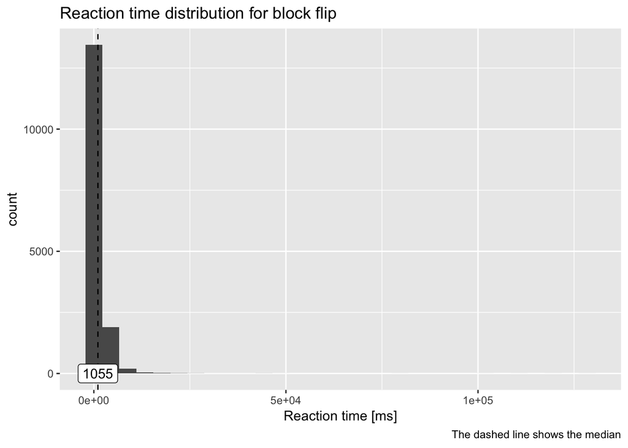

```r
flip_rt %>%
  flatten_dbl() %>%
  enframe() %>%
  ggplot(aes(x = value)) +
    geom_histogram() +
  geom_vline(xintercept = flip_stats$md_flip,
             linetype = "dashed") +
  labs(caption = "The dashed line shows the median",
       x = "Reaction time [ms]",
              title = "Reaction time distribution for block flip") +
  annotate("label", y = 0, x = flip_stats$md_flip,
           label = round(flip_stats$md_flip))
```

### 1.1.2 block 2: “hold as long as you can”

```r
hold_rt <- rawdata$NW03_01 %>%
  map(~str_split(., pattern = ",")) %>%
  map(~`[[`(., 1)) %>%
  map(~ parse_number(.))
```

Get descriptives:

```r
hold_rt_sum <- hold_rt %>%
  flatten_dbl() %>%
  enframe(name = "trial", value = "rt") %>%
  drop_na() %>%
  summarise(type = "hold",
            md_rt = median(rt),
            mean_rt = mean(rt),
            sd_rt = sd(rt),
            iqr_rt = IQR(rt)
            )


hold_rt_sum
```

```
## # A tibble: 1 x 5
##   type  md_rt mean_rt sd_rt iqr_rt
##   <chr> <dbl>   <dbl> <dbl>  <dbl>
## 1 hold   4295   5350. 4809.  4621.
```

Visualize it:

[figure not shown]

```r
hold_rt %>%
  flatten_dbl() %>%
  enframe() %>%
  ggplot(aes(x = value)) +
    geom_histogram() +
  geom_vline(xintercept = hold_rt_sum$md_rt[1],
             linetype = "dashed") +
  labs(caption = "The dashed line shows the median",
       x = "Reaction time [ms]",
       title = "Reaction time distribution for block FLIP") +
  annotate("label", y = 0, x = hold_rt_sum$md_rt[1],
           label = round(hold_rt_sum$md_rt[1]))
```

# 2 Shape to very long data frame

## 2.1 Build rt data frame

Build reaction time (rt) data frame, where each flip (of each person) is a row

Name list elements:

```r
name_list_elements <- paste0("id_",1:143)

names(flip_rt) <- name_list_elements
names(hold_rt) <- name_list_elements
```

### 2.1.1 Flip data frame

```r
rt_flip_long <- enframe(flip_rt) %>%
  unnest() %>%
  add_column(type = "flip")

rt_flip_long
```

```
## # A tibble: 15,652 x 3
##    name  value type
##    <chr> <dbl> <chr>
##  1 id_1   7050 flip
##  2 id_1   4857 flip
##  3 id_1    776 flip
##  4 id_1   1185 flip
##  5 id_1    231 flip
##  6 id_1    221 flip
##  7 id_1    180 flip
##  8 id_1    203 flip
##  9 id_1    387 flip
## 10 id_1    195 flip
## # … with 15,642 more rows
```

### 2.1.2 Hold data frame

```r
rt_hold_long <- enframe(hold_rt) %>%
  unnest() %>%
  add_column(type = "hold")

rt_hold_long
```

```
## # A tibble: 4,487 x 3
##    name  value type
##    <chr> <dbl> <chr>
##  1 id_1  24771 hold
##  2 id_1   6371 hold
##  3 id_1  20708 hold
##  4 id_1   8869 hold
##  5 id_1  10777 hold
##  6 id_1   8835 hold
##  7 id_1   8982 hold
##  8 id_1   3548 hold
##  9 id_1  22205 hold
## 10 id_1   3268 hold
## # … with 4,477 more rows
```

### 2.1.3 Merge hold and flip data frames

```r
rt_long <- rt_flip_long %>%
  bind_rows(rt_hold_long)
```

Get ID variable back:

```r
rt_long2 <- rt_long %>%
  separate(name, into = c("dummy", "id"), sep = "_") %>%
  remove_cols(dummy) %>%
  mutate(id = as.numeric(id)) %>%
  rename(rt = value)

rt_long2
```

```
## # A tibble: 20,139 x 3
##       id    rt type
##    <dbl> <dbl> <chr>
##  1     1  7050 flip
##  2     1  4857 flip
##  3     1   776 flip
##  4     1  1185 flip
##  5     1   231 flip
##  6     1   221 flip
##  7     1   180 flip
##  8     1   203 flip
##  9     1   387 flip
## 10     1   195 flip
## # … with 20,129 more rows
```

# 3 Build master data frame on level 1 data

Each row is a flip, so a very long data frame.

This type of data frame is built because (I assume) modeling functions can only digest data where a row is a level 1 data (ie., a flip)

```r
rawdata_long <- rawdata %>%
  full_join(rt_long2)
```

Is the length of the resulting data frame equal to the length of the RT data frame?

```r
nrow(rawdata_long) == nrow(rt_long2)
```

```
## [1] TRUE
```

# 4 Compute mindfulness score (as MEAN)

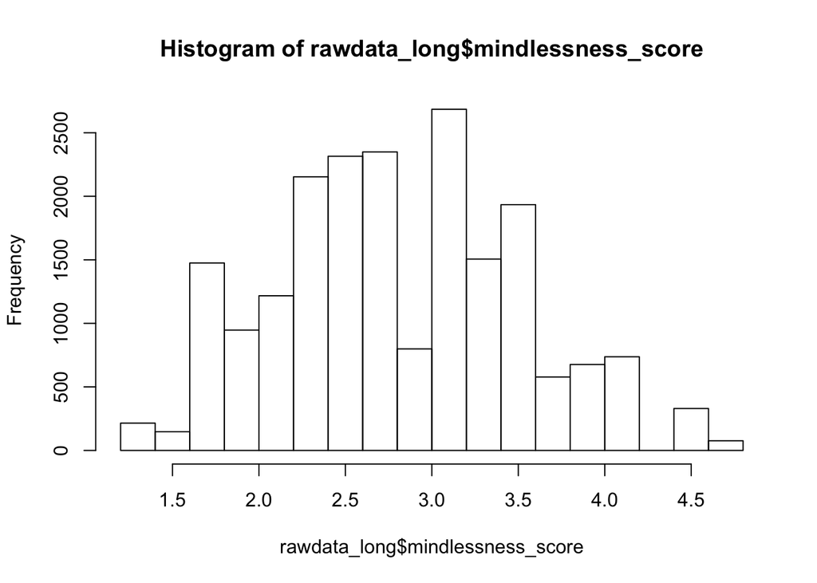

```r
rawdata_long <- rawdata_long %>%
  row_means(MA01_01:MA01_17, n = .9,
            var = "mindlessness_score")

hist(rawdata_long$mindlessness_score)
```

How many NAs?

```r
sum(is.na(rawdata_long$mindlessness_score))
```

```
## [1] 0
```

Recode mindfulness score (originally, it is code as mindlessness):

```r
rawdata_long2 <- rawdata_long %>%
  mutate(mindfulness_score = 7 - mindlessness_score)
```

# 5 Rename variables

## 5.1 Mindfulness training experience

Does the person trains mindfulness (regularly)?

```r
rawdata_long3 <- rawdata_long2 %>%
  mutate(mindfulness_training = ifelse(PE06 == 1, 1, 0))
```

Training YES: 1 Training NO: 0

# 6 Collapse data on person-level

Remove level 1 data:

```r
d_person <- select(rawdata_long3, -c(rt, type)) %>%
  distinct()
d_person
```

```
## # A tibble: 143 x 56
##       id  CASE SERIAL REF   QUESTNNR MODE  STARTED             PE01_01
##    <dbl> <dbl> <lgl>  <lgl> <chr>    <chr> <dttm>                <dbl>
##  1     1   194 NA     NA    base     inte… 2018-12-22 12:46:41      25
##  2     2   212 NA     NA    base     inte… 2018-12-22 13:05:44      34
##  3     3   219 NA     NA    base     inte… 2018-12-22 13:16:03      48
##  4     4   224 NA     NA    base     inte… 2018-12-22 13:23:32      34
##  5     5   226 NA     NA    base     inte… 2018-12-22 13:25:33      24
##  6     6   228 NA     NA    base     inte… 2018-12-22 13:25:56      25
##  7     7   229 NA     NA    base     inte… 2018-12-22 13:26:27      32
##  8     8   233 NA     NA    base     inte… 2018-12-22 13:29:01      22
##  9     9   241 NA     NA    base     inte… 2018-12-22 13:40:01      27
## 10    10   244 NA     NA    base     inte… 2018-12-22 13:46:24      59
## # … with 133 more rows, and 48 more variables: PE02 <dbl>, PE03 <dbl>,
## #   PE04 <dbl>, PE05 <dbl>, PE06 <dbl>, PE07_01 <chr>, PE08 <dbl>,
## #   PE08_06 <chr>, PE09 <dbl>, MA01_01 <dbl>, MA01_02 <dbl>,
## #   MA01_03 <dbl>, MA01_04 <dbl>, MA01_05 <dbl>, MA01_07 <dbl>,
## #   MA01_08 <dbl>, MA01_09 <dbl>, MA01_10 <dbl>, MA01_12 <dbl>,
## #   MA01_13 <dbl>, MA01_14 <dbl>, MA01_15 <dbl>, MA01_16 <dbl>,
## #   MA01_17 <dbl>, NW03_01 <chr>, NW04_01 <chr>, TIME001 <dbl>,
## #   TIME002 <dbl>, TIME003 <dbl>, TIME004 <dbl>, TIME005 <dbl>,
## #   TIME006 <dbl>, TIME007 <dbl>, TIME008 <dbl>, TIME_SUM <dbl>,
## #   MAILSENT <lgl>, LASTDATA <dttm>, FINISHED <dbl>, Q_VIEWER <dbl>,
## #   LASTPAGE <dbl>, MAXPAGE <dbl>, MISSING <dbl>, MISSREL <dbl>,
## #   TIME_RSI <dbl>, DEG_TIME <dbl>, mindlessness_score <dbl>,
## #   mindfulness_score <dbl>, mindfulness_training <dbl>
```

Summarise level 1 data on person level and on type (block) level, that is, on level 2.

block HOLD

```r
rt_summary_hold <- rawdata_long3 %>%
  group_by(id, type) %>%
  filter(type == "hold") %>%
  summarise(rt_md_hold = median(rt, na.rm = TRUE),
            rt_mean_hold = mean(rt, na.rm = TRUE),
            rt_iqr_hold = IQR(rt, na.rm = TRUE),
            rt_sd_hold = IQR(rt, na.rm = TRUE))  %>%
  ungroup() %>%
  select(-type)

rt_summary_hold
```

```
## # A tibble: 143 x 5
##       id rt_md_hold rt_mean_hold rt_iqr_hold rt_sd_hold
##    <dbl>      <dbl>        <dbl>       <dbl>      <dbl>
##  1     1      8835        10047.       8888       8888
##  2     2      5690.        6756.       5293.      5293.
##  3     3      7787         7187.       4286.      4286.
##  4     4      5247         5106.       2955       2955
##  5     5      1792         1792           0          0
##  6     6      3119         3968.       3247       3247
##  7     7      3694.        5753.       6334.      6334.
##  8     8      4342.        6872.       8506.      8506.
##  9     9      2581         3119.       2229       2229
## 10    10      2814         3765.       2754       2754
## # … with 133 more rows
```

block FLIP

```r
rt_summary_flip <- rawdata_long3 %>%
  group_by(id, type) %>%
  filter(type == "flip") %>%
  summarise(rt_md_flip = median(rt, na.rm = TRUE),
            rt_mean_flip = mean(rt, na.rm = TRUE),
            rt_iqr_flip = IQR(rt, na.rm = TRUE),
            rt_sd_flip = IQR(rt, na.rm = TRUE)) %>%
  ungroup() %>%
  select(-type)

rt_summary_flip
```

```
## # A tibble: 143 x 5
##       id rt_md_flip rt_mean_flip rt_iqr_flip rt_sd_flip
##    <dbl>      <dbl>        <dbl>       <dbl>      <dbl>
##  1     1       286         3353.        443        443
##  2     2      1041         1200.        351.       351.
##  3     3      1379         1546.        500        500
##  4     4      1090.        1322.        432.       432.
##  5     5      5130        43222       58107      58107
##  6     6      1287         1676.        974        974
##  7     7      1635         1777.        698        698
##  8     8      4518.        6046.       7393       7393
##  9     9      1382         1756.       1132       1132
## 10    10      1280.        2044.        459.       459.
## # … with 133 more rows
```

Join the summary data frames:

```r
rt_summary <- rt_summary_hold %>%
  full_join(rt_summary_flip) %>%
  ungroup()
```

Summarise level 1 data on person level and on type (block) level, that is, on level 2:

```r
rt_summary <- rawdata_long3 %>%
  group_by(id, type) %>%
  summarise(rt_md = median(rt, na.rm = TRUE),
            rt_mean = mean(rt, na.rm = TRUE),
            rt_iqr = IQR(rt, na.rm = TRUE),
            rt_sd = IQR(rt, na.rm = TRUE))
rt_summary
```

```
## # A tibble: 286 x 6
## # Groups:   id [143]
##       id type  rt_md rt_mean rt_iqr  rt_sd
##    <dbl> <chr> <dbl>   <dbl>  <dbl>  <dbl>
##  1     1 flip   286    3353.   443    443
##  2     1 hold  8835   10047.  8888   8888
##  3     2 flip  1041    1200.   351.   351.
##  4     2 hold  5690.   6756.  5293.  5293.
##  5     3 flip  1379    1546.   500    500
##  6     3 hold  7787    7187.  4286.  4286.
##  7     4 flip  1090.   1322.   432.   432.
##  8     4 hold  5247    5106.  2955   2955
##  9     5 flip  5130   43222  58107  58107
## 10     5 hold  1792    1792      0      0
## # … with 276 more rows
```

## 6.1 Add to data frames

### 6.1.1 add to l2 (short) data frame

Add rt summaries to person/type level (level 2) data frame:

```r
d_person_rt_sum <- d_person %>%
  full_join(rt_summary) %>%
  select(id, contains("rt"), mindfulness_score, mindfulness_training, everything() )
d_person_rt_sum
```

```
## # A tibble: 286 x 61
##       id STARTED             rt_md rt_mean rt_iqr  rt_sd mindfulness_sco…
##    <dbl> <dttm>              <dbl>   <dbl>  <dbl>  <dbl>            <dbl>
##  1     1 2018-12-22 12:46:41  286    3353.   443    443              4.33
##  2     1 2018-12-22 12:46:41 8835   10047.  8888   8888              4.33
##  3     2 2018-12-22 13:05:44 1041    1200.   351.   351.             3.87
##  4     2 2018-12-22 13:05:44 5690.   6756.  5293.  5293.             3.87
##  5     3 2018-12-22 13:16:03 1379    1546.   500    500              4.53
##  6     3 2018-12-22 13:16:03 7787    7187.  4286.  4286.             4.53
##  7     4 2018-12-22 13:23:32 1090.   1322.   432.   432.             3.93
##  8     4 2018-12-22 13:23:32 5247    5106.  2955   2955              3.93
##  9     5 2018-12-22 13:25:33 5130   43222  58107  58107              4
## 10     5 2018-12-22 13:25:33 1792    1792      0      0              4
## # … with 276 more rows, and 54 more variables: mindfulness_training <dbl>,
## #   CASE <dbl>, SERIAL <lgl>, REF <lgl>, QUESTNNR <chr>, MODE <chr>,
## #   PE01_01 <dbl>, PE02 <dbl>, PE03 <dbl>, PE04 <dbl>, PE05 <dbl>,
## #   PE06 <dbl>, PE07_01 <chr>, PE08 <dbl>, PE08_06 <chr>, PE09 <dbl>,
## #   MA01_01 <dbl>, MA01_02 <dbl>, MA01_03 <dbl>, MA01_04 <dbl>,
## #   MA01_05 <dbl>, MA01_07 <dbl>, MA01_08 <dbl>, MA01_09 <dbl>,
## #   MA01_10 <dbl>, MA01_12 <dbl>, MA01_13 <dbl>, MA01_14 <dbl>,
## #   MA01_15 <dbl>, MA01_16 <dbl>, MA01_17 <dbl>, NW03_01 <chr>,
## #   NW04_01 <chr>, TIME001 <dbl>, TIME002 <dbl>, TIME003 <dbl>,
## #   TIME004 <dbl>, TIME005 <dbl>, TIME006 <dbl>, TIME007 <dbl>,
## #   TIME008 <dbl>, TIME_SUM <dbl>, MAILSENT <lgl>, LASTDATA <dttm>,
## #   FINISHED <dbl>, Q_VIEWER <dbl>, LASTPAGE <dbl>, MAXPAGE <dbl>,
## #   MISSING <dbl>, MISSREL <dbl>, TIME_RSI <dbl>, DEG_TIME <dbl>,
## #   mindlessness_score <dbl>, type <chr>
```

### 6.1.2 Add to l1 (long) data frame

```r
rawdata_long4 <- rawdata_long3 %>%
  full_join(rt_summary) %>%
  select(id, contains("rt"), mindfulness_score, mindfulness_training, everything() )
rawdata_long4
```

```
## # A tibble: 20,139 x 62
##       id STARTED                rt rt_md rt_mean rt_iqr rt_sd
##    <dbl> <dttm>              <dbl> <dbl>   <dbl>  <dbl> <dbl>
##  1     1 2018-12-22 12:46:41  7050   286   3353.    443   443
##  2     1 2018-12-22 12:46:41  4857   286   3353.    443   443
##  3     1 2018-12-22 12:46:41   776   286   3353.    443   443
##  4     1 2018-12-22 12:46:41  1185   286   3353.    443   443
##  5     1 2018-12-22 12:46:41   231   286   3353.    443   443
##  6     1 2018-12-22 12:46:41   221   286   3353.    443   443
##  7     1 2018-12-22 12:46:41   180   286   3353.    443   443
##  8     1 2018-12-22 12:46:41   203   286   3353.    443   443
##  9     1 2018-12-22 12:46:41   387   286   3353.    443   443
## 10     1 2018-12-22 12:46:41   195   286   3353.    443   443
## # … with 20,129 more rows, and 55 more variables: mindfulness_score <dbl>,
## #   mindfulness_training <dbl>, CASE <dbl>, SERIAL <lgl>, REF <lgl>,
## #   QUESTNNR <chr>, MODE <chr>, PE01_01 <dbl>, PE02 <dbl>, PE03 <dbl>,
## #   PE04 <dbl>, PE05 <dbl>, PE06 <dbl>, PE07_01 <chr>, PE08 <dbl>,
## #   PE08_06 <chr>, PE09 <dbl>, MA01_01 <dbl>, MA01_02 <dbl>,
## #   MA01_03 <dbl>, MA01_04 <dbl>, MA01_05 <dbl>, MA01_07 <dbl>,
## #   MA01_08 <dbl>, MA01_09 <dbl>, MA01_10 <dbl>, MA01_12 <dbl>,
## #   MA01_13 <dbl>, MA01_14 <dbl>, MA01_15 <dbl>, MA01_16 <dbl>,
## #   MA01_17 <dbl>, NW03_01 <chr>, NW04_01 <chr>, TIME001 <dbl>,
## #   TIME002 <dbl>, TIME003 <dbl>, TIME004 <dbl>, TIME005 <dbl>,
## #   TIME006 <dbl>, TIME007 <dbl>, TIME008 <dbl>, TIME_SUM <dbl>,
## #   MAILSENT <lgl>, LASTDATA <dttm>, FINISHED <dbl>, Q_VIEWER <dbl>,
## #   LASTPAGE <dbl>, MAXPAGE <dbl>, MISSING <dbl>, MISSREL <dbl>,
## #   TIME_RSI <dbl>, DEG_TIME <dbl>, type <chr>, mindlessness_score <dbl>
```

# 7 Save data to disk

[output not shown]